# Author : Farhad Ahmad Qureshi

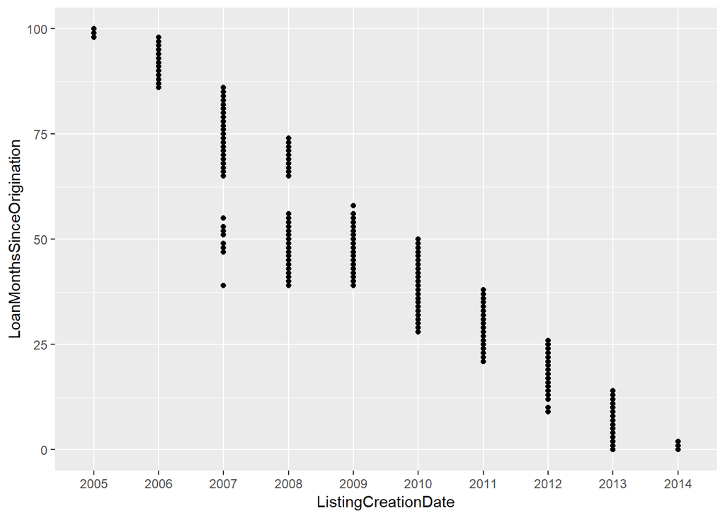

There seem to some more delinquicy from 2005 to 2010 so will be interesting to see the data for good and default borrowers in multivariate analysis for the same plot.

## CreditScoreRangeUpper vs Investors

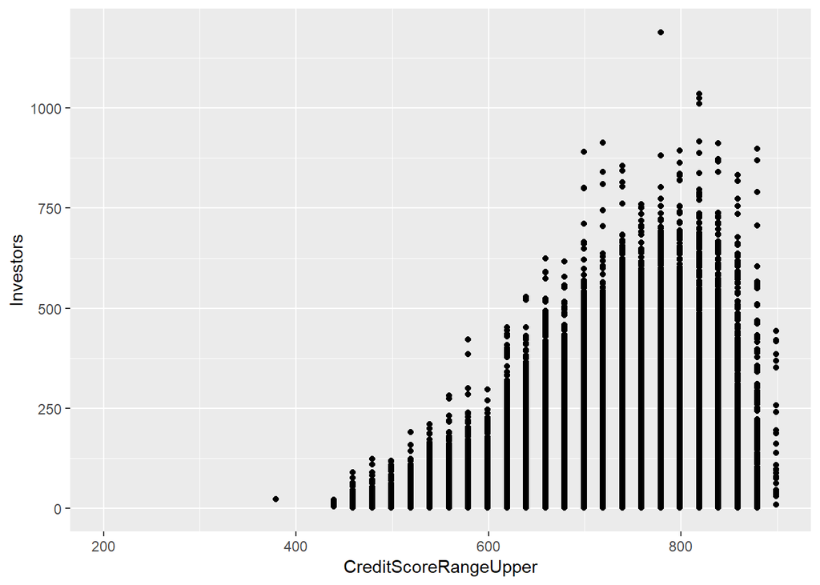

### IncomeRange vs Investors

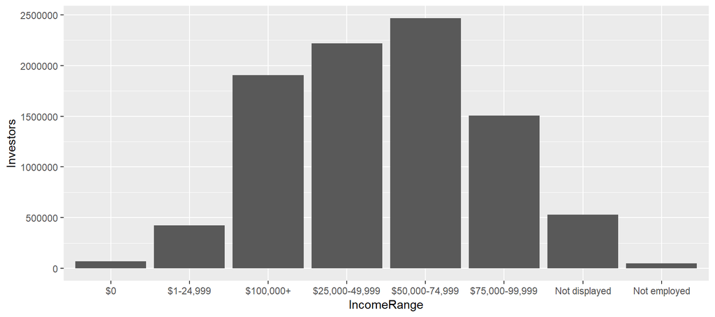

Most investors investing into the employed masses.

## LoanOriginalAmount vs Investors

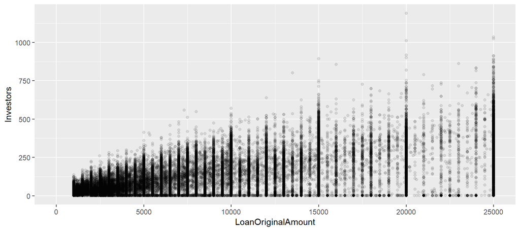

As expected the more the loan amount the more investors. (Excluding top 1 % loan amount)

## LoanOriginalAmount vs LP_CustomerPayments

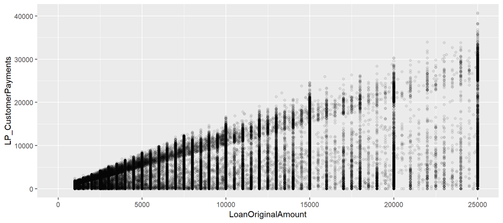

Higher the loan amount more payments are made by the borrower. (Excluding top 1 % loan amount)

## Summary of Bivariate plots

The employed borrowers are mostly the highest in defaulters

Number of investors increase with high credit scores

When analyzing loan months since origination, there was a spike around 24 and after 60 months. So I will later  
check their loan terms to see which loan terms usually has most defaulters.

### What was the strongest relationship you found?

Investors and credit scores

The strong relation was between Loan months since origination and listing creation.

LP_customerpayments and investors

Investors and credit score

Income range and investors

# Multivariate Plots Section

# Correlation Analysis

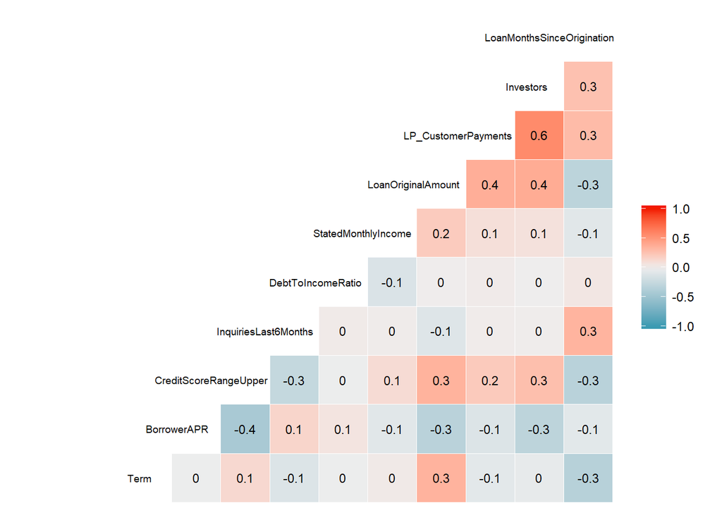

Looking at the correlation coefficients of quantitative variables only. There seem to be some relation of investors with lp_customerpayments as well as loan original amount. There is inverse relation between debt to income ratio and monthly income as expected.There is inverse relation between loan original amount and inquiries last 6 months. CreditScoreRangeUpper and InquiriesLast6Months does not seem to have any relation but still I am curious to see it by standing so beginning the analysis with these.

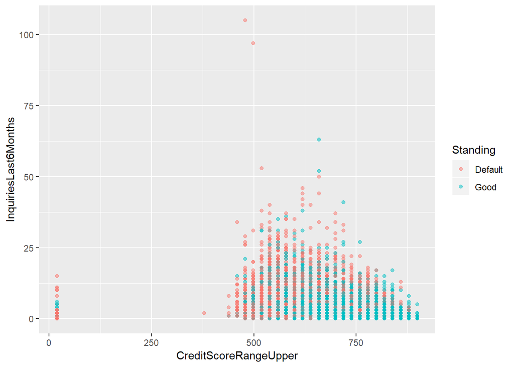

As expected more defaulters on lower side of the rating but there are also some on the higher side!

## LoanMonthsSinceOrigination vs Term vs Standing

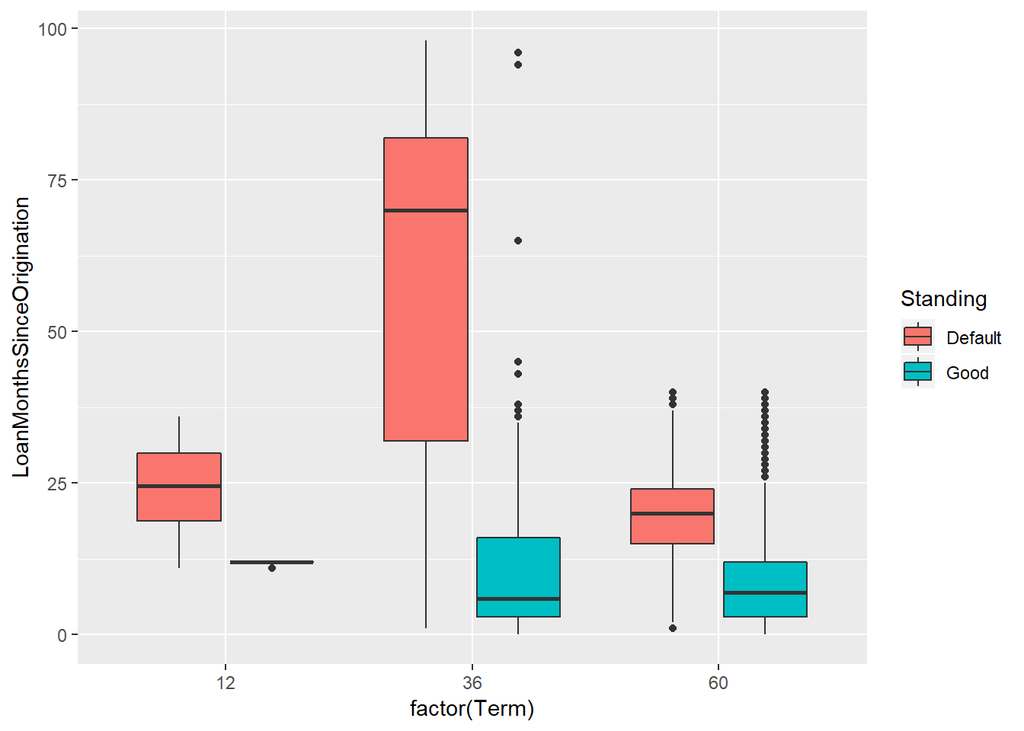

Excluding the borrowers who have completed their loans to make the comparison. Defaulters as expected spent more months than what they expressed initially to pay off their loans. Most defaulters are for the 36 term duration since most loans are also for this term. Median for loan months since origination for defaulters of 36 month term is around 70. Which means 50% are below this and 50% above this.

The 60 month duration term doesn’t have any borrower exceeding the limit of 60 months. For 12 month term almost all defaulters have exceeded the duration of term. Months for defaulters is always high as compared to non defaulters.

## Investors vs LP_CustomerPayments by Standing

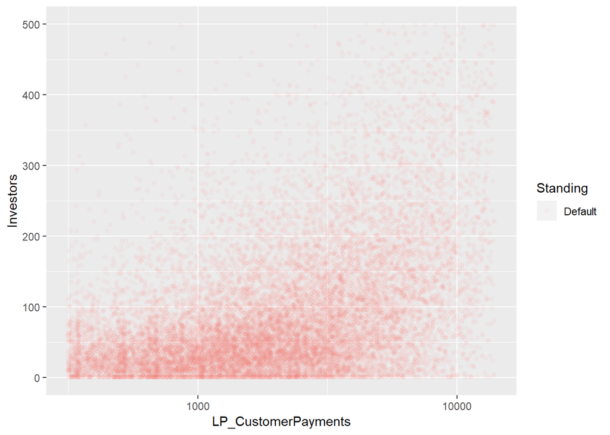

As shown by the correlation there was some relation between these two. So only looking at defaulted borrowers with x axis log transformed and not including bottom 10% LP_customerpayments. So there is some interaction between these two.

## StatedMonthlyIncome vs DebtToIncomeRatio by Standing

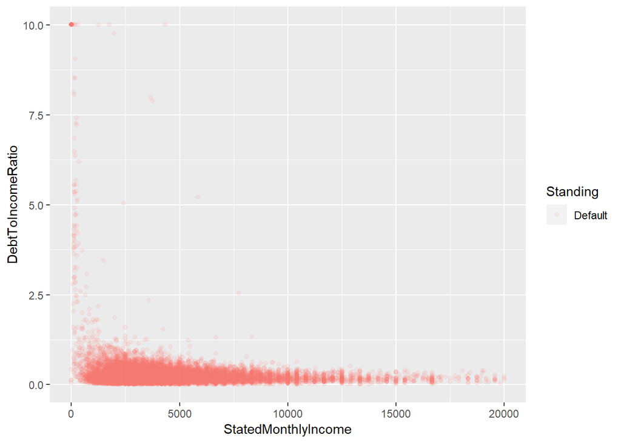

Only looking at the default borrowers. Most of them are within 0 - 10k range. There are also some with income under 2500 who have high debt to income ratios as expected. As seen from correlation coefficient there is inverse relation between these two which can be expected.

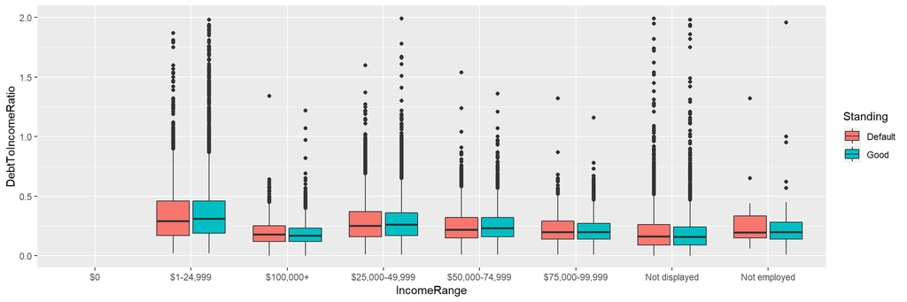

The average Prosper borrower according to this dataset has 27.60% DTI, although the maximum allowable is 50% as per their website the ratio is below 1 for all income range borrowers but I do see outliers in each income range.

## ListingCreationDate vs LoanMonthsSinceOrigination by Standing

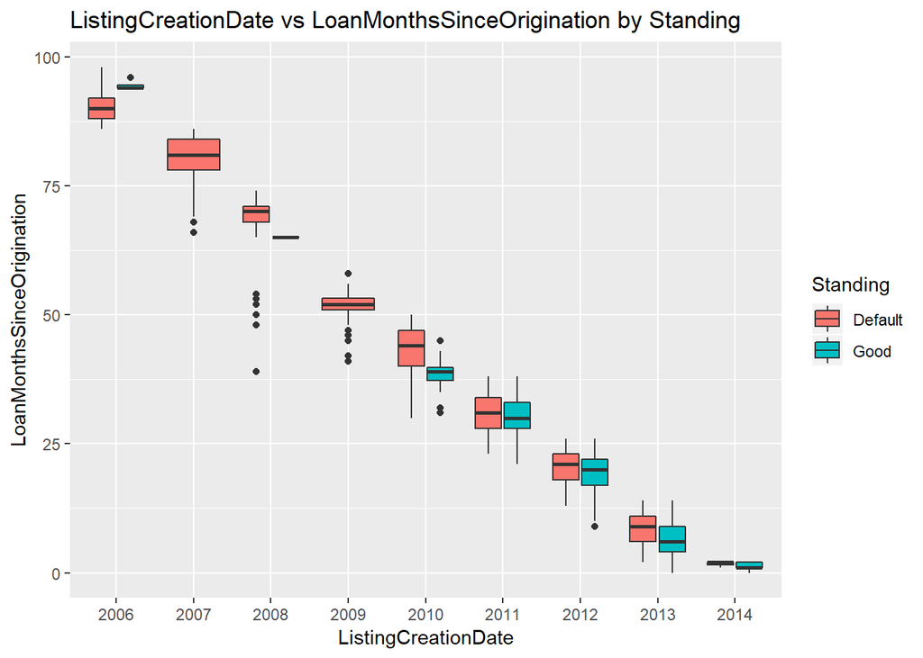

Most borrowers that went delinquent were from 2006 - 2008 (not including those who have completed their terms) that is seen by the increased number of months for these years. The skewness again could also be due to the financial crisis period (2008-09). From 2009 inwards the number of defaulters have almost always conceded more months than those in good standing which could be expected.

## ListingCreationDate vs LoanCurrentDaysDelinquent by Standing

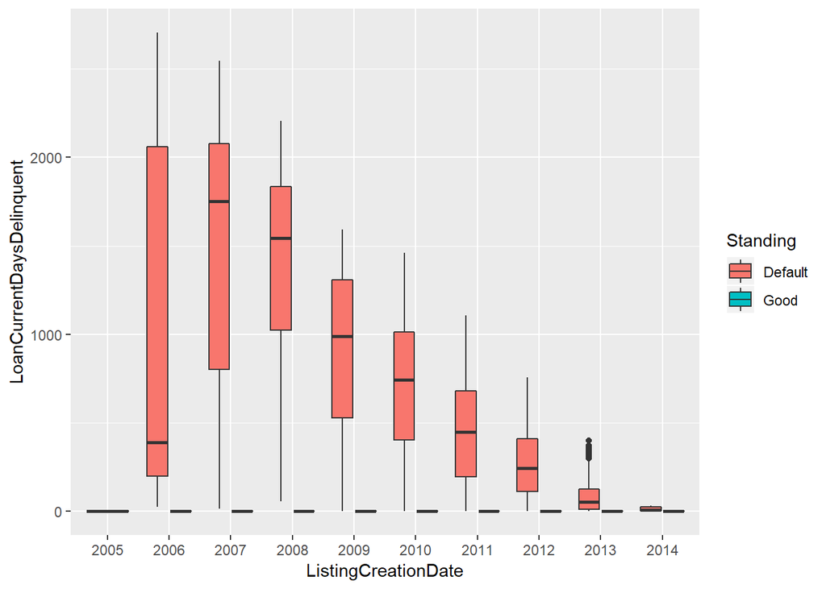

Loans created in 2006 - 2008 were delinquent for most of the days.

## CreditScoreRangeUpper vs Investors by Standing

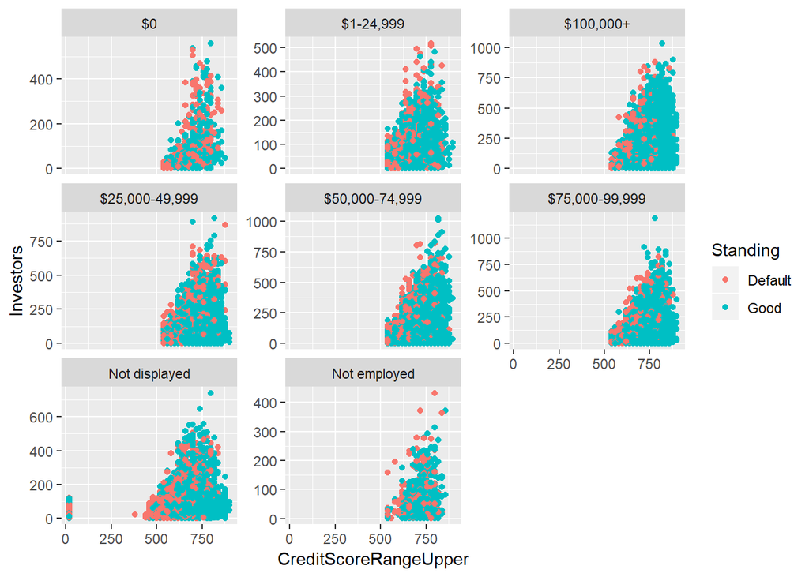

There is a direct relation between credit score and number of investors with defaulters being at lower credit rating usually as compared to good standing accounts.

## ListingCreationDate vs DebtToIncomeRatio by Standing

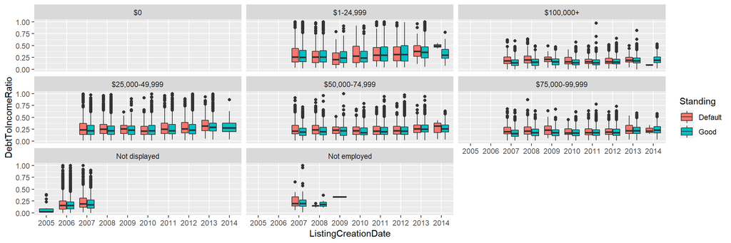

Not displayed category does not exist after 2007. There are a large number of outliers above a ratio of 1 so limited analysis to a ratio of 1 only.

## ListingCreationDate vs BorrowerAPR by Standing

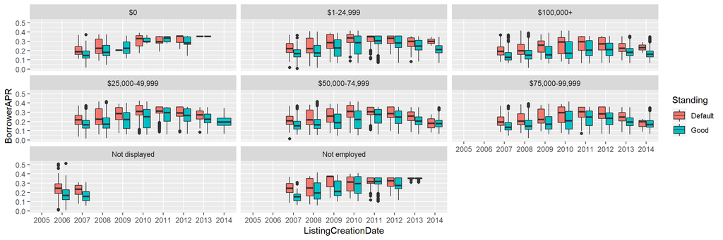

Defaulters have more APR almost always as compared to the others. This is not because they have taken high loan amounts as seen previously in the bivariate analysis section the number of defaulters were almost always less than the good standing borrowers for the same amount range.

Analyzing borrower APR with credit score to see if this has something do with high rates for bad standing borrowers also APR with loan original amount will be checked.

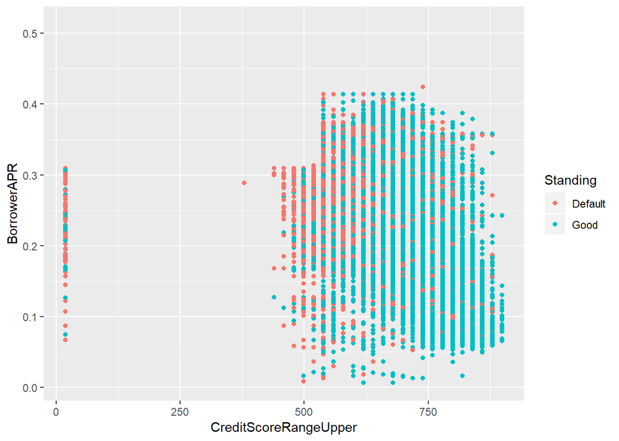

```r
by(plds$BorrowerAPR,plds$Standing,summary)
```

```
## plds$Standing: Default
##    Min. 1st Qu.  Median    Mean 3rd Qu.    Max.
## 0.00864 0.18977 0.25627 0.25384 0.31033 0.50633
## --------------------------------------------------------
## plds$Standing: Good
##    Min. 1st Qu.  Median    Mean 3rd Qu.    Max.    NA's
## 0.00653 0.15016 0.20268 0.21178 0.27246 0.51229      25
```

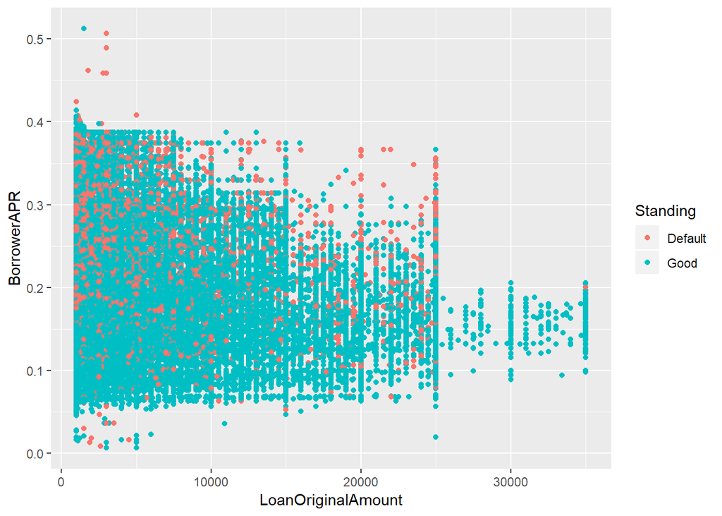

# Final Plots and Summary

## ListingCreationDate vs LoanMonthsSinceOrigination by Standing

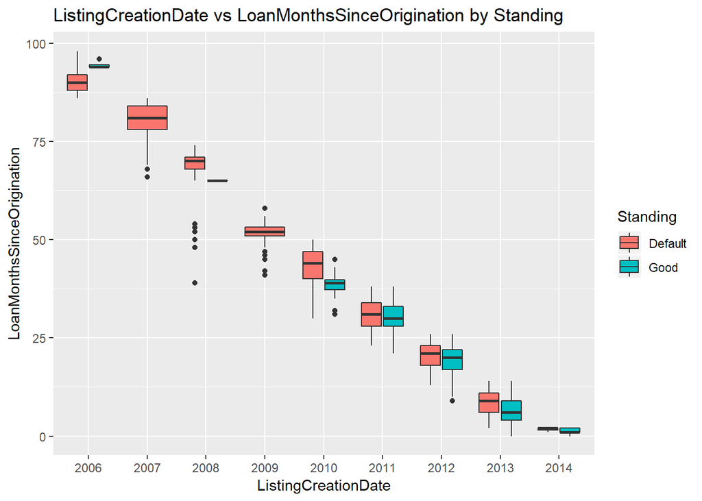

### Description One

The plot does not include those borrowers who have completed their terms in order to see the current borrowers only as those who have completed their terms will be causing a bias. This plot shows borrowers with default standing had taken most number of months in almost every year. The skewness seen might be due to the financial crisis from 2008 - 09 but the number of defaulters since then has been on the fall.

## CreditScoreRangeUpper vs Investors by Standing

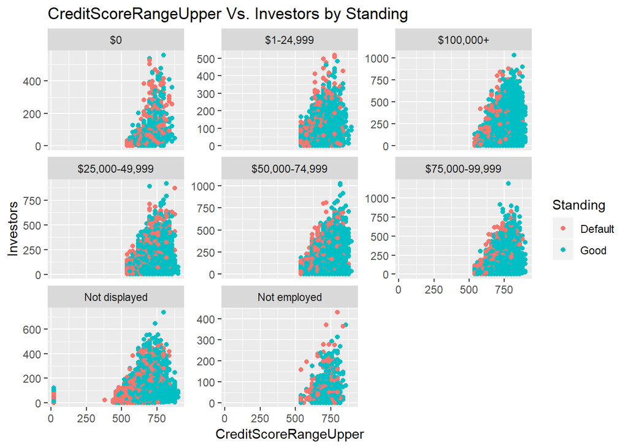

### Description Two

This plot shows the trend of investors on selecting borrowers. There is almost always trust shown by investors above 500 score. Also there are a few outliers in Not Displayed maybe due to the fact that this category only existed until 2007 and after this more transparency was introduced and borrowers were made to declare their income.

## ListingCreationDate vs BorrowerAPR by Standing

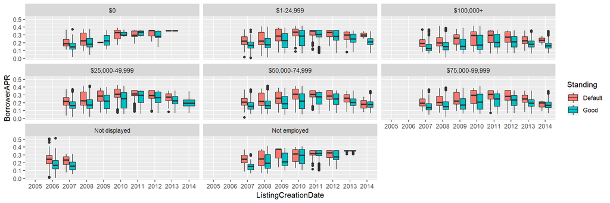

### Description Three

Defaulters have more APR almost always as compared to the others. This is not because they have taken high loan amounts as seen previously in the bivariate analysis section the number of defaulters were almost always less than the good standing borrowers for the same amount range. Analyzing borrower APR with credit score also did not show any unexpected trends that could be associated with this.Also, there wasn’t any specific relation between loan original amount and APR for the same loan amount. ——

# Reflection

The dataset contained around 100,000 observations and 81 variables. Given the original range of keeping the analysis restricted to 10-15 variables was difficult since it was hard to decide which variables to keep. I tried to keep the variables within the prescribed range but some features required more analysis to come to any conclusion.

There were few financial terms that were hard to understand so first some reserach was conducted to get familiar with them.

Comparing the default borrowers with those in good standing revealed a lot of insights about what factors actually contribute towards delinquicy such as BorrowerAPR, Credit Score and inquiries to name a few. Strict policies could further be set up in order to further reduce the number of defaulters.

The dataset was full of interesting information such as the criteria followed by investors to lend to borrowers with high credit scores (500 ). There was a positive relation between loan original amount and number of investors showing more investors contribute towards more loan amount not causing a burden in case if only was lending.Also, payments made by customers including all service charges showed positive relation with the number of investors.

There is still a lot room for further analysis such as seeing the categories of the purpose loan was taken and average earning per state could be included as a feature.

# References

https://prosper.zendesk.com/hc/en-us/articles/210013963

https://www.investopedia.com/terms/

https://stats.stackexchange.com/questions/11406/boxplot-with-respect-to-two-factors-using-ggplot2-in-r

https://www.orchardplatform.com/blog/2014519lender-yield-prosper/